# index

Meishu Zhao

2024-09-11

**Data**

```r
## Install the tidyverse package if you don't have it
if (!require("tidyverse", quietly = TRUE)) {
    install.packages("tidyverse")
}
library("tidyverse")
```

```r
if (!require("tidytuesdayR", quietly = TRUE)) {
    install.packages("tidytuesdayR")
}

if (!require("remotes", quietly = TRUE)) {
    install.packages("remotes")
}

if (!require("tidytuesdayR", quietly = TRUE)) {
    remotes::install_github("dslc-io/tidytuesdayR")
}
```

```r
library("here")
# tests if a directory named "data" exists locally
if (!dir.exists(here("data"))) {
    dir.create(here("data"))
}

# saves data only once (not each time you knit a R Markdown)
if (!file.exists(here("data", "chocolate.RDS"))) {
    url_csv <- "https://raw.githubusercontent.com/rfordatascience/tidytuesday/master/data/2022/2022-01-18/chocolate.csv"
    chocolate <- readr::read_csv(url_csv)

    # save the file to RDS objects
    saveRDS(chocolate, file = here("data", "chocolate.RDS"))
}
```

```r
chocolate <- readRDS(here("data", "chocolate.RDS"))
as_tibble(chocolate)
```

```
## # A tibble: 2,530 × 10
##      ref company_manufacturer company_location review_date
##    <dbl> <chr>                <chr>                  <dbl>
##  1  2454 5150                 U.S.A.                  2019
##  2  2458 5150                 U.S.A.                  2019
##  3  2454 5150                 U.S.A.                  2019
##  4  2542 5150                 U.S.A.                  2021
##  5  2546 5150                 U.S.A.                  2021
##  6  2546 5150                 U.S.A.                  2021
##  7  2542 5150                 U.S.A.                  2021
##  8   797 A. Morin             France                  2012
##  9   797 A. Morin             France                  2012
## 10  1011 A. Morin             France                  2013
## # ℹ 2,520 more rows
## # ℹ 6 more variables: country_of_bean_origin <chr>,
## #   specific_bean_origin_or_bar_name <chr>, cocoa_percent <chr>,
## #   ingredients <chr>, most_memorable_characteristics <chr>, rating <dbl>
```

```r
glimpse(chocolate)
```

```
## Rows: 2,530
## Columns: 10
## $ ref                              <dbl> 2454, 2458, 2454, 2542, 2546, 2546, 2…
## $ company_manufacturer             <chr> "5150", "5150", "5150", "5150", "5150…
## $ company_location                 <chr> "U.S.A.", "U.S.A.", "U.S.A.", "U.S.A.…
## $ review_date                      <dbl> 2019, 2019, 2019, 2021, 2021, 2021, 2…
## $ country_of_bean_origin           <chr> "Tanzania", "Dominican Republic", "Ma…
## $ specific_bean_origin_or_bar_name <chr> "Kokoa Kamili, batch 1", "Zorzal, bat…
## $ cocoa_percent                    <chr> "76%", "76%", "76%", "68%", "72%", "8…
## $ ingredients                      <chr> "3- B,S,C", "3- B,S,C", "3- B,S,C", "…
## $ most_memorable_characteristics   <chr> "rich cocoa, fatty, bready", "cocoa, …
## $ rating                           <dbl> 3.25, 3.50, 3.75, 3.00, 3.00, 3.25, 3…
```

## Part 1

**1. Make a histogram of the rating scores to visualize the overall distribution of scores. Change the number of bins from the default to 10, 15, 20, and 25. Pick on the one that you think looks the best. Explain what the difference is when you change the number of bins and explain why you picked the one you did.**

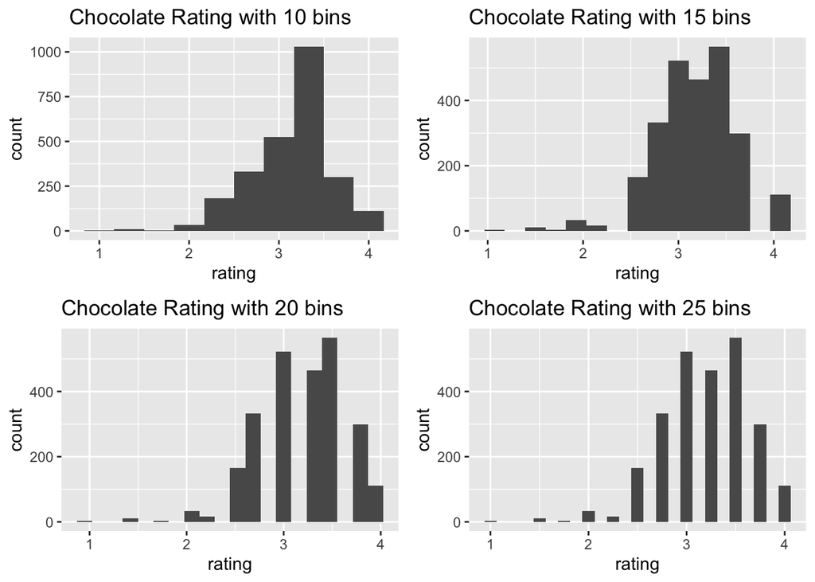

```r
library(ggplot2)
if (!require("gridExtra", quietly = TRUE)) {
    install.packages("gridExtra")
}
library(gridExtra)

bin_10 <- ggplot(chocolate, aes(x = rating)) +
  geom_histogram(bins = 10) +
  ggtitle("Chocolate Rating with 10 bins")

bin_15 <- ggplot(chocolate, aes(x = rating)) +
  geom_histogram(bins = 15) +
  ggtitle("Chocolate Rating with 15 bins")

bin_20 <- ggplot(chocolate, aes(x = rating)) +
  geom_histogram(bins = 20) +
  ggtitle("Chocolate Rating with 20 bins")

bin_25 <- ggplot(chocolate, aes(x = rating)) +
  geom_histogram(bins = 25) +
  ggtitle("Chocolate Rating with 25 bins")

grid.arrange(bin_10, bin_15, bin_20, bin_25, ncol=2)
```

I would choose 15 bins. As the number of bins increases, there’s a higher chance that some ratings will have no counts, creating gaps that make it harder to observe the overall trend of the scores. On the other hand, using only 10 bins provides less detail compared to 15, which strikes a good balance between showing enough information and maintaining a clear view of the overall distribution.

**2. Consider the countries where the beans originated from. How many reviews come from each country of bean origin?**

```r
chocolate %>%
  count(country_of_bean_origin)
```

```
## # A tibble: 62 × 2
##    country_of_bean_origin     n
##    <chr>                  <int>
##  1 Australia                  3
##  2 Belize                    76
##  3 Blend                    156
##  4 Bolivia                   80
##  5 Brazil                    78
##  6 Burma                      1
##  7 Cameroon                   3
##  8 China                      1
##  9 Colombia                  79
## 10 Congo                     11
## # ℹ 52 more rows
```

**3. What is average rating scores from reviews of chocolate bars that have Ecuador as country_of_bean_origin in this dataset? For this same set of reviews, also calculate (1) the total number of reviews and (2) the standard deviation of the rating scores. Your answer should be a new data frame with these three summary statistics in three columns. Label the name of these columns mean, sd, and total.**

```r
Ecuador_summary = chocolate %>%
  filter(country_of_bean_origin == "Ecuador") %>%
  summarise(mean = mean(rating,na.rm = TRUE),
            sd = sd(rating),
            total = n())
Ecuador_summary
```

```
## # A tibble: 1 × 3
##    mean    sd total
##   <dbl> <dbl> <int>
## 1  3.16 0.512   219
```

**4. Which company location makes the best chocolate (or has the highest ratings on average) with beans from Ecuador?**

```r
chocolate %>%
  filter(country_of_bean_origin == "Ecuador") %>%
  group_by(company_location) %>%
  summarize(location_rating = mean(rating, na.rm = TRUE)) %>%
  arrange(desc(location_rating))
```

```
## # A tibble: 25 × 2
##    company_location location_rating
##    <chr>                      <dbl>
##  1 Australia                   3.81
##  2 Switzerland                 3.75
##  3 New Zealand                 3.62
##  4 Hungary                     3.5
##  5 Israel                      3.5
##  6 Netherlands                 3.5
##  7 Singapore                   3.5
##  8 South Korea                 3.33
##  9 Canada                      3.28
## 10 U.S.A.                      3.26
## # ℹ 15 more rows
```

Australia makes the best chocolate (or has the highest ratings on average) with beans from Ecuador.

**5.Calculate the average rating across all country of origins for beans. Which top 3 countries (for bean origin) have the highest ratings on average?**

```r
chocolate %>%
  group_by(country_of_bean_origin) %>%
  summarize(country_rating = mean(rating)) %>%
  arrange(desc(country_rating)) %>%
  head(3)
```

```
## # A tibble: 3 × 2
##   country_of_bean_origin country_rating
##   <chr>                           <dbl>
## 1 Tobago                           3.62
## 2 China                            3.5
## 3 Sao Tome & Principe              3.5
```

Tobago, China, and Sao Tome&Principle have the highest ratings on average.

**6. Following up on the previous problem, now remove any countries of bean origins that have less than 10 chocolate bar reviews. Now, which top 3 countries have the highest ratings on average?**

```r
chocolate %>%
  group_by(country_of_bean_origin) %>%
  filter(n() >= 10) %>%
  summarize(avg_rating = mean(rating)) %>%
  arrange(desc(avg_rating)) %>%
  head(3)
```

```
## # A tibble: 3 × 2
##   country_of_bean_origin avg_rating
##   <chr>                       <dbl>
## 1 Solomon Islands              3.45
## 2 Congo                        3.32
## 3 Cuba                         3.29
```

In countries with 10 reviews, Solomon Islands, Congo, and Cuba have the highest ratings on average.

**7.or this last part, let’s explore the relationship between percent chocolate and ratings.Use the functions in dplyr, tidyr, and lubridate to perform the following steps to the chocolate dataset: Identify the countries of bean origin with at least 50 reviews. Remove reviews from countries are not in this list.Using the variable describing the chocolate percentage for each review, create a new column that groups chocolate percentages into one of four groups: (i) <60%, (ii) >=60 to <70%, (iii) >=70 to <90%, and (iii) >=90% (Hint check out the substr() function in base R and the case_when() function from dplyr – see example below). Using the new column described in #2, re-order the factor levels (if needed) to be starting with the smallest percentage group and increasing to the largest percentage group (Hint check out the fct_relevel() function from forcats).For each country, make a set of four side-by-side boxplots plotting the groups on the x-axis and the ratings on the y-axis. These plots should be faceted by country.On average, which category of chocolate percentage is most highly rated? Do these countries mostly agree or are there disagreements? Hint: You may find the case_when() function useful in this part, which can be used to map values from one variable to different values in a new variable (when used in a mutate() call).**

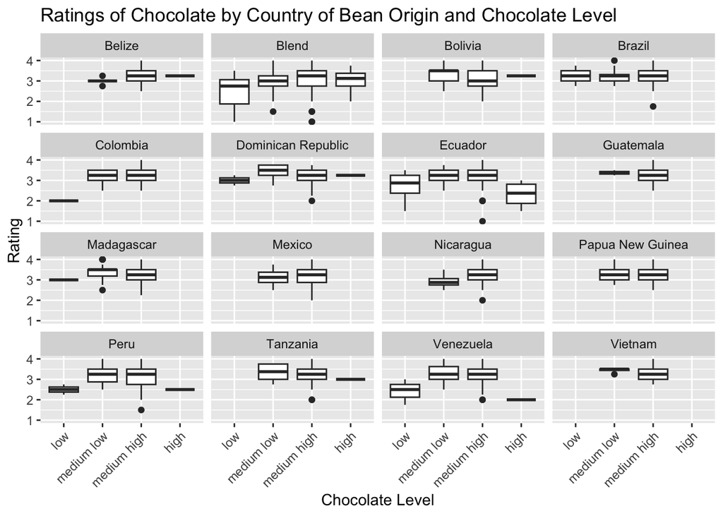

```r
#1.countries of bean origin with at least 50 reviews
countires_50 <- chocolate %>%
  group_by(country_of_bean_origin) %>%
  filter(n() >= 50)

#2.
chocolate_level <- countires_50 %>%
  ungroup() %>%
  mutate(
    chocolate_percentages = case_when(
      as.numeric(substr(cocoa_percent, 1, 2)) <  60 ~ "low",
      as.numeric(substr(cocoa_percent, 1, 2)) >= 60 &
        as.numeric(substr(cocoa_percent, 1, 2)) < 70 ~ "medium low",
      as.numeric(substr(cocoa_percent, 1, 2)) >= 70 &
        as.numeric(substr(cocoa_percent, 1, 2)) < 90 ~ "medium high",
      as.numeric(substr(cocoa_percent, 1, 2)) >= 90 ~ "high"
    )
  )


chocolate_level <- chocolate_level %>%
  mutate(
    chocolate_percentages = fct_relevel(chocolate_percentages, "low", "medium low", "medium high", "high")
  )

#4.
ggplot(chocolate_level, aes(x = chocolate_percentages, y = rating)) +
  geom_boxplot() +
  facet_wrap(~ country_of_bean_origin) +
  labs(title = "Ratings of Chocolate by Country of Bean Origin and Chocolate Level",
       x = "Chocolate Level",
       y = "Rating") +
  theme(axis.text.x = element_text(angle = 45, hjust = 1))
```

```r
#rating by chocolate
average_ratings_by_group <- chocolate_level %>%
  group_by(chocolate_percentages) %>%
  summarize(avg_rating = mean(rating)) %>%
  arrange(desc(avg_rating))
print(average_ratings_by_group)
```

```
## # A tibble: 4 × 2
##   chocolate_percentages avg_rating
##   <fct>                      <dbl>
## 1 medium low                  3.25
## 2 medium high                 3.22
## 3 high                        2.75
## 4 low                         2.66
```

The medium low, 60% to 70% group(medium low) has the highest rating. Most countries agrees with this result, although some countries have the mediums high(70% to 90%) the highest rating.

## Part 2 Join two datasets together

The goal of this part of the assignment is to join two datasets together. gapminder is a R package that contains an excerpt from the Gapminder data. **1.Use this dataset it to create a new column called continent in our chocolate dataset1 that contains the continent name for each review where the country of bean origin is.** **2.Only keep reviews that have reviews from countries of bean origin with at least 10 reviews.** **3.Also, remove the country of bean origin named “Blend”.** **4.Make a set of violin plots with ratings on the y-axis and continents on the x-axis.**

```r
if (!require("gapminder", quietly = TRUE)) {
    install.packages("gapminder")
}
library(gapminder)
gapminder
```

```
## # A tibble: 1,704 × 6
##    country     continent  year lifeExp      pop gdpPercap
##    <fct>       <fct>     <int>   <dbl>    <int>     <dbl>
##  1 Afghanistan Asia       1952    28.8  8425333      779.
##  2 Afghanistan Asia       1957    30.3  9240934      821.
##  3 Afghanistan Asia       1962    32.0 10267083      853.
##  4 Afghanistan Asia       1967    34.0 11537966      836.
##  5 Afghanistan Asia       1972    36.1 13079460      740.
##  6 Afghanistan Asia       1977    38.4 14880372      786.
##  7 Afghanistan Asia       1982    39.9 12881816      978.
##  8 Afghanistan Asia       1987    40.8 13867957      852.
##  9 Afghanistan Asia       1992    41.7 16317921      649.
## 10 Afghanistan Asia       1997    41.8 22227415      635.
## # ℹ 1,694 more rows
```

```r
gapminder_data <- gapminder %>%
  select(country, continent) %>%
  distinct()

chocolate_10_no_blend <- chocolate %>%
  group_by(country_of_bean_origin) %>%
  filter(n() >= 10 & country_of_bean_origin != 'Blend')

chocolate_join_continent <- chocolate_10_no_blend  %>%
  left_join(gapminder_data, by = c("country_of_bean_origin" = "country"))

missing_countries <- chocolate_join_continent %>%
  filter(is.na(continent)) %>%
  distinct(country_of_bean_origin)
print(missing_countries) #11 countries with NA
```

```
## # A tibble: 11 × 1
## # Groups:   country_of_bean_origin [11]
##    country_of_bean_origin
##    <chr>
##  1 Fiji
##  2 Papua New Guinea
##  3 Sao Tome
##  4 Vanuatu
##  5 Trinidad
##  6 Belize
##  7 Grenada
##  8 Congo
##  9 Solomon Islands
## 10 St. Lucia
## 11 U.S.A.
```

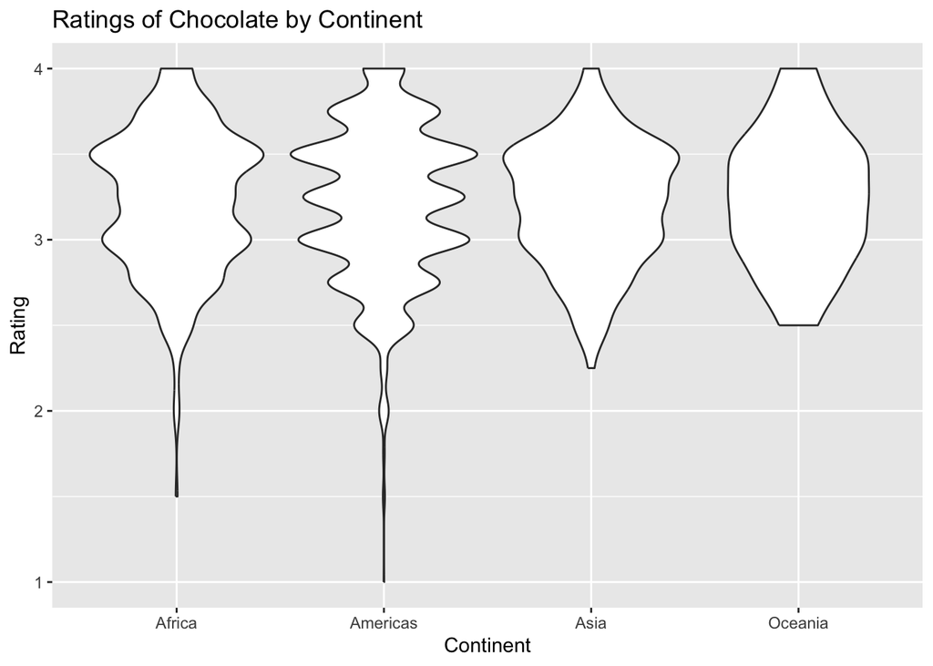

```r
chocolate_and_continent <- chocolate_join_continent %>%
  mutate(continent = case_when(
    country_of_bean_origin %in% c("Fiji", "Papua New Guinea", "Vanuatu", "Solomon Islands") ~ "Oceania",
    country_of_bean_origin %in% c("Trinidad", "Belize", "Grenada", "St. Lucia", "U.S.A.") ~ "Americas",
    country_of_bean_origin %in% c("Congo", "Sao Tome") ~ "Africa",
    TRUE ~ continent
  ))

ggplot(chocolate_and_continent , aes(x = continent, y = rating)) +
  geom_violin() +
  labs(title = "Ratings of Chocolate by Continent",
       x = "Continent",
       y = "Rating")
```

**Convert wide data into long data. The goal of this part of the assignment is to take a dataset that is either messy or simply not tidy and to make them tidy datasets. The objective is to gain some familiarity with the functions in the dplyr, tidyr packages. You may find it helpful to review the section on pivoting data from wide to long format and vice versa.**

**We are going to create a set of features for us to plot over time. Use the functions in dplyr and tidyr to perform the following steps to the chocolate dataset:**

**1.Create a new set of columns titled beans, sugar, cocoa_butter, vanilla, letchin, and salt that contain a 1 or 0 representing whether or not that review for the chocolate bar contained that ingredient (1) or not (0).** **2.Create a new set of columns titled char_cocoa, char_sweet, char_nutty, char_creamy, char_roasty, char_earthy that contain a 1 or 0 representing whether or not that the most memorable characteristic for the chocolate bar had that word (1) or not (0). For example, if the word “sweet” appears in the most_memorable_characteristics, then record a 1, otherwise a 0 for that review in the char_sweet column (Hint: check out str_detect() from the stringr package).** **3.For each year (i.e. review_date), calculate the mean value in each new column you created across all reviews for that year. (Hint: If all has gone well thus far, you should have a dataset with 16 rows and 13 columns).** **4.Convert this wide dataset into a long dataset with a new feature and mean_score column.**

```r
#1
chocolate_part_3 <- chocolate %>%
  mutate(
    beans = if_else(is.na(ingredients) | !str_detect(ingredients, "B"), 0, 1),
    sugar = if_else(is.na(ingredients) | !str_detect(ingredients, "\\bS\\b"), 0, 1),
    cocoa_butter = if_else(is.na(ingredients) | !str_detect(ingredients, "C"), 0, 1),
    vanilla = if_else(is.na(ingredients) | !str_detect(ingredients, "V"), 0, 1),
    letchin = if_else(is.na(ingredients) | !str_detect(ingredients, "L"), 0, 1),
    salt = if_else(is.na(ingredients) | !str_detect(ingredients, "Sa"), 0, 1)
  )

#2
chocolate_part_3 <- chocolate_part_3 %>%
  mutate(
    char_cocoa = ifelse(str_detect(most_memorable_characteristics, "cocoa"), 1, 0),
    char_sweet = ifelse(str_detect(most_memorable_characteristics, "sweet"), 1, 0),
    char_nutty = ifelse(str_detect(most_memorable_characteristics, "nutty"), 1, 0),
    char_creamy = ifelse(str_detect(most_memorable_characteristics, "creamy"), 1, 0),
    char_roasty = ifelse(str_detect(most_memorable_characteristics, "roasty"), 1, 0),
    char_earthy = ifelse(str_detect(most_memorable_characteristics, "earthy"), 1, 0)
  )

#3
chocolate_summary <- chocolate_part_3 %>%
  group_by(review_date) %>%
  summarize(
    mean_beans = mean(beans, na.rm = TRUE),
    mean_sugar = mean(sugar, na.rm = TRUE),
    mean_cocoa_butter = mean(cocoa_butter, na.rm = TRUE),
    mean_vanilla = mean(vanilla, na.rm = TRUE),
    mean_letchin = mean(letchin, na.rm = TRUE),
    mean_salt = mean(salt, na.rm = TRUE),
    mean_char_cocoa = mean(char_cocoa, na.rm = TRUE),
    mean_char_sweet = mean(char_sweet, na.rm = TRUE),
    mean_char_nutty = mean(char_nutty, na.rm = TRUE),
    mean_char_creamy = mean(char_creamy, na.rm = TRUE),
    mean_char_roasty = mean(char_roasty, na.rm = TRUE),
    mean_char_earthy = mean(char_earthy, na.rm = TRUE)
  )

print(chocolate_summary) # 16*13
```

```
## # A tibble: 16 × 13
##    review_date mean_beans mean_sugar mean_cocoa_butter mean_vanilla mean_letchin
##          <dbl>      <dbl>      <dbl>             <dbl>        <dbl>        <dbl>
##  1        2006      0.968      0.968             0.903       0.694        0.694
##  2        2007      0.945      0.945             0.767       0.548        0.384
##  3        2008      0.913      0.902             0.75        0.359        0.511
##  4        2009      0.919      0.919             0.772       0.325        0.341
##  5        2010      0.855      0.855             0.709       0.227        0.391
##  6        2011      0.939      0.939             0.693       0.160        0.160
##  7        2012      0.928      0.928             0.675       0.186        0.124
##  8        2013      0.967      0.956             0.776       0.208        0.295
##  9        2014      0.984      0.984             0.644       0.0688       0.121
## 10        2015      0.986      0.979             0.546       0.0599       0.120
## 11        2016      0.982      0.977             0.594       0.0507       0.106
## 12        2017      0.981      0.981             0.562       0.0286       0.133
## 13        2018      0.987      0.987             0.596       0.0614       0.132
## 14        2019      1          1                 0.679       0.0259       0.202
## 15        2020      1          1                 0.568       0.0370       0.0247
## 16        2021      1          0.994             0.646       0.0114       0.0800
## # ℹ 7 more variables: mean_salt <dbl>, mean_char_cocoa <dbl>,
## #   mean_char_sweet <dbl>, mean_char_nutty <dbl>, mean_char_creamy <dbl>,
## #   mean_char_roasty <dbl>, mean_char_earthy <dbl>
```

```r
#4
chocolate_long <- chocolate_summary %>%
  pivot_longer(cols = -review_date, names_to = "feature", values_to = "mean_score")

print(chocolate_long)
```

```
## # A tibble: 192 × 3
##    review_date feature           mean_score
##          <dbl> <chr>                  <dbl>
##  1        2006 mean_beans            0.968
##  2        2006 mean_sugar            0.968
##  3        2006 mean_cocoa_butter     0.903
##  4        2006 mean_vanilla          0.694
##  5        2006 mean_letchin          0.694
##  6        2006 mean_salt             0
##  7        2006 mean_char_cocoa       0.210
##  8        2006 mean_char_sweet       0.161
##  9        2006 mean_char_nutty       0.0323
## 10        2006 mean_char_creamy      0.242
## # ℹ 182 more rows
```

## Part 4: Data visualization

**In this part of the project, we will continue to work with our now tidy song dataset from the previous part.** **Use the functions in ggplot2 package to make a scatter plot of the mean_scores (y-axis) over time (x-axis). There should be one plot (facet) for each feature. For full credit, your plot should include:An overall title for the plot and a subtitle summarizing key trends that you found. Also include a caption in the figure with your name.Both the observed points for the mean_score, but also a smoothed non-linear pattern of the trend.**

**All plots should be shown in the one figure** **There should be an informative x-axis and y-axis label. Consider playing around with the theme() function to make the figure shine, including playing with background colors, font, etc. See https://github.com/lcolladotor/jhustatcomputing/issues/4 for an example on how you can choose colors if you have too many categories.** **Don’t worry about the ordering of the rows or columns. Depending on whether you use gather() or pivot_longer(), the order of your output may differ from what is printed above. As long as the result is a tidy data set, that is sufficient.**

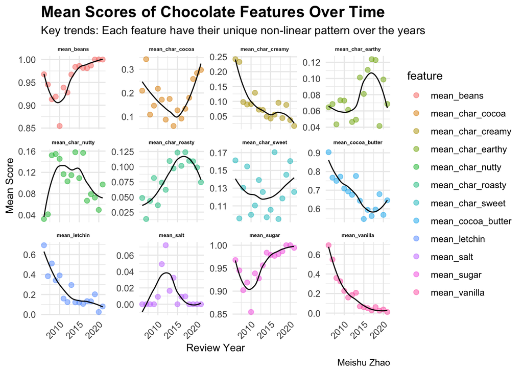

```r
ggplot(chocolate_long, aes(x = review_date,
                           y = mean_score)) +
  geom_point(aes(color = feature), alpha = 1/2, size = 2) +
  geom_smooth(method = "loess", color = "black", se = FALSE, size=0.5) +
  facet_wrap(~ feature, scales = "free_y") +
  labs(
    title = "Mean Scores of Chocolate Features Over Time",
    subtitle = "Key trends: Each feature have their unique non-linear pattern over the years",
    x = "Review Year",
    y = "Mean Score",
    caption = "Meishu Zhao"
  ) +
  theme_minimal() +
  theme(
    plot.title = element_text(face = "bold", size = 15),
    axis.title = element_text(size = 10),
    strip.text = element_text(size = 5, face = "bold"), #resize facet title
    axis.text.x = element_text(angle = 45, hjust = 1) #rotate year
  )
```

## Part 5: Make the worst plot you can!

**This sounds a bit crazy I know, but I want this to try and be FUN! Instead of trying to make a “good” plot, I want you to explore your creative side and make a really awful data visualization in every way. :)**

**Using the chocolate dataset (or any of the modified versions you made throughout this assignment or anything else you wish you build upon it):**

**Make the absolute worst plot that you can. You need to customize it in at least 7 ways to make it awful.** **In your document, write 1 - 2 sentences about each different customization you added (using bullets – i.e. there should be at least 7 bullet points each with 1-2 sentences), and how it could be useful for you when you want to make an awesome data visualization.**

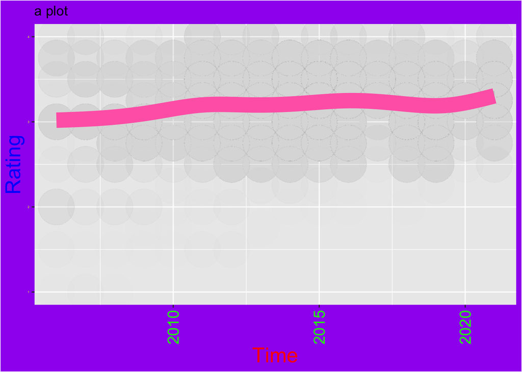

```r
bad_plot <- chocolate %>%
  ggplot(aes(
  x=review_date,
  y=rating
))
bad_plot +
  geom_point(size = 16, alpha = 1 / 99, color="grey") +
  geom_smooth(se = TRUE, size = 07, color = "hotpink") +
  labs(
    title="a plot",
    x="Time",
    y="Rating"
  ) +
  theme(
    plot.background = element_rect(fill = "purple"),
    axis.title.x = element_text(size = 20, color = "red"),
    axis.title.y = element_text(size = 20, color = "blue"),
    axis.text.x = element_text(angle = 90, vjust = 0.5, hjust = 1, color = "green", size = 15),
    axis.text.y = element_text(size = 3, color = "yellow")
  )
```

## Part 6: Make my plot a better plot!

**The goal is to take my sad looking plot and make it better! If you’d like an example, here is a tweet I came across of someone who gave a talk about how to zhoosh up your ggplots.** **1. You need to customize it in at least 7 ways to make it better.** **2.In your document, write 1 - 2 sentences about each different customization you added (using bullets – i.e. there should be at least 7 bullet points each with 1-2 sentences), describing how you improved it.**

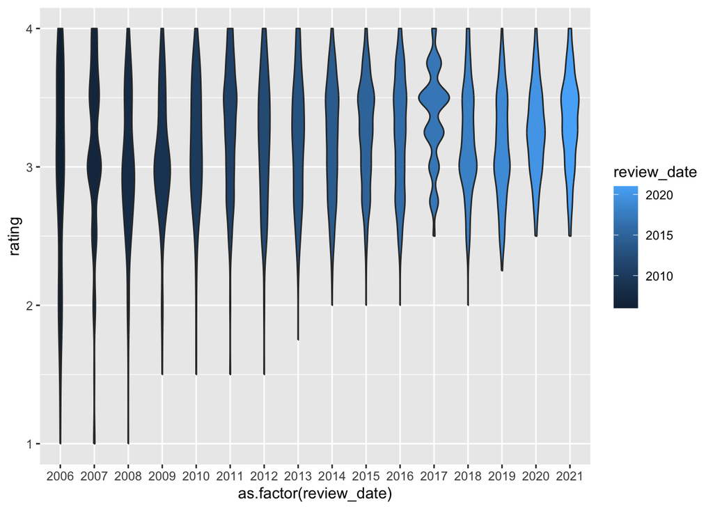

```r
chocolate %>%
    ggplot(aes(
        x = as.factor(review_date),
        y = rating,
        fill = review_date
    )) +
    geom_violin()
```

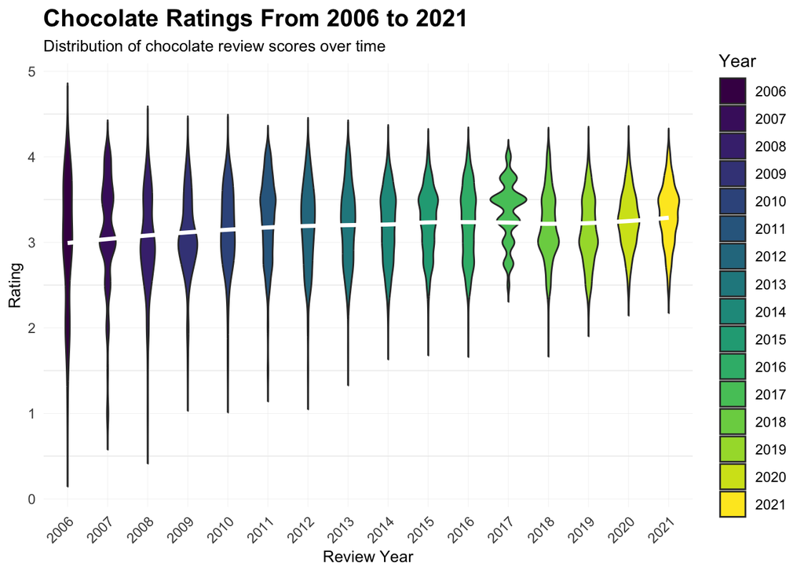

```r
if (!require("viridis", quietly = TRUE)) {
    install.packages("viridis")
}
library(viridis)

average_ratings <- chocolate %>%
  group_by(review_date) %>%
  summarize(avg_rating = mean(rating, na.rm = TRUE))

chocolate %>%
  ggplot(aes(
    x = as.factor(review_date),
    y = rating,
    fill = as.factor(review_date)
  )) +
  geom_violin(trim = FALSE) +

  scale_fill_viridis_d(option = "viridis") +
  labs(
    title = "Chocolate Ratings From 2006 to 2021",
    subtitle = "Distribution of chocolate review scores over time",
    x = "Review Year",
    y = "Rating",
    fill = "Year"
  ) +
 geom_smooth(aes(group = 1), method = "loess", color = "white", size = 1.2, se = FALSE, show.legend = FALSE) +
  theme_minimal() +
  theme(
    plot.title = element_text(size = 15, face = "bold"),
    plot.subtitle = element_text(size = 10),
    axis.title.x = element_text(size = 10),
    axis.title.y = element_text(size = 10),
    axis.text.x = element_text(angle = 45, hjust = 1),
    panel.grid.major = element_line(size = 0.1)
  )
```